# Atmosphere Numerical and Data Analysis Answers

```python
import numpy as np
import matplotlib.pyplot as plt
from SciServer import CasJobs
from SciServer import Authentication
from io import StringIO
from astropy.table import Table
import requests
```

## 1. Differential chromatic aberration

*Based on answer by Dou Liu*

The equations in [Stone (1996)](https://ui.adsabs.harvard.edu/#abs/1996PASP..108.1051S/abstract) relate index of refraction to zenith angle, and give the dependence of index of refraction on local conditions and wavelength. They claim this to be accurate under most conditions better than 0.150 arcsec for zenith angles less than 75 deg, and better than 0.010 arcsec for zenith angles less the 65 deg.

These equations allow you to relate the *apparent* zenith angle (which is what the star would be at if there were no atmosphere) to the *observed* zenith angle (which is what the star should be at accounting for the atmosphere). The observed zenith angle is always smaller than the apparent zenith angle. We define the refraction as the apparent minus the observed.

Note that astropy, starlink, IRAF, and other astronomical tools have built into them refraction calculators. Those other tools are the ones you should actually use!

$\kappa$ is the ratio of the gravity at the observing site to the sea-level gravity at the earth's equator. $$ \kappa=\frac{g_0}{g}=1+0.005302\sin^2\phi-5.83\times 10^{-6}\sin^2(2\phi)-3.15\times10^{-7}h $$

```python
def kappa(phi, h):
    """Gravitational constant at observatory relative to equator

    Parameters
    ----------

    phi : np.float32
        latitude of observatory (deg)

    h : np.float32
        height of observatory from sea level (meters)
"""
    k = 1 + 5.302 / 1E3 * np.sin(phi)**2 - 5.83 / 1E6 * np.sin(2. * phi)**2 - 3.15 / 1E7 * h
    return k
```

```python
def beta(T):
    """Scaling of temperature

    Parameters
    ----------

    T : np.float32
        temperature in K
"""
    return(4.5908 / 1E6 * T)
```

The angular difference in arcsec due to chromatic atmospheric difference refraction is $$R(\lambda)\simeq \kappa(n(\lambda)-1)(1-\beta)\tan z-\kappa(1-n(\lambda)\left(\beta-\frac{1}{2}(n(\lambda)-1)\right)\tan^3z$$ where $z$ is the zenith angle and $n$ is the index of refraction.

This formula accounts for the spherical shape of the Earth and atmosphere, which is why the gravity and the height enter the calculation.

```python
def refraction(lam=5500., T=285., Ps=1000., RH=0.2,
               phi=0., h=0., z=0., n=None):
    """Refraction calculation

    Parameters
    ----------

    lam : np.float32
        wavelength (A) (default 5500.)

    T : np.float32
        temperature in K (default 285.)

    Ps : np.float32
        pressure (mbar) (default 1000.)

    RH : np.float32
        relative humidity (default 0.2)

    phi : np.float32
        latitude (deg) (default 0.)

    h : np.float32
        height from sea level (default 0.)

    z : np.float32
        zenith angle (deg) (default 0.)

    n : np.float32
        index of refraction (by default sets with local_ref())

    Returns:
    -------

    R : np.float32
        refraction in arcsec (difference of apparent to observed zenith angle)
"""
    if(n is None):
        n = local_ref(lam, T, Ps, RH)
    zrad = z * np.pi / 180.
    k = kappa(phi, h)
    b = beta(T)
    R = k * (n - 1) * (1 - b) * np.tan(zrad) - k * (1 - n) * (b - (n - 1) / 2) * np.tan(zrad)**3
    R = R * 180. / np.pi * 3600.
    return R
```

```python
def local_ref(lam=5500., T=285., Ps=1000., RH=0.2):
    """Local refraction index

    Parameters
    ----------

    lam : np.float32
        wavelength (A) (default 5500.)

    T : np.float32
        temperature in K (default 285.)

    Ps : np.float32
        pressure (mbar) (default 1000.)

    RH : np.float32
        relative humidity (default 0.2)
    Returns:
    -------

    n : np.float32
        index of refraction (by default sets with local_ref())
"""
    sigma=10**4/lam
    Pw=RH/1E4*np.exp(77.3450+0.0057*T-7235.0/T)/T**8.2
    Ds=(1+(Ps-Pw)*(57.90/1E8-9.3250*1E-4/T+0.25844/T**2))*(Ps-Pw)/T
    Dw=(1+Pw*(1+3.7/1E4*Pw)*(-2.37321/1E3+2.23366/T-710.792/T**2+7.75141*10**4/T**3))*Pw/T
    n=1+((2371.34+683939.7/(130-sigma)+4547.3/(38.9-sigma**2))*Ds
       +(6487.31+58.058*sigma**2-0.71150*sigma**4+0.08851*sigma**6)*Dw)*1E-8
    return n
```

It is instructive to compare this refraction to what we would derive just from Snell's law for a plane-parallel atmosphere. This is much simpler to derive. We start with: $$ n_{\rm space} \sin z_{\rm app} = n_{\rm obs} \sin z_{\rm obs} $$ and noting that $n_{\rm space} = 1$: $$ z_{\rm obs} = \sin^{-1} \left(\frac{\sin z_{\rm app}}{n_{\rm obs}}\right) $$ Note that in the plane-parallel case, only the index of refraction local to the observatory matters.

It is easy to show that for $n \approx 1$: $$ R = z_{\rm app} - z_{\rm obs} \approx (n - 1) \tan z_{\rm app} $$ This shows why the leading term of Stone's equation looks the way that it does.

```python
def refraction_pp(lam=5500., T=285., Ps=1000., RH=0.2,
                  z=0., n=None):
    """Refraction calculation in plane-parallel approximation

    Parameters
    ----------

    lam : np.float32
        wavelength (A) (default 5500.)

    T : np.float32
        temperature in K (default 285.)

    Ps : np.float32
        pressure (mbar) (default 1000.)

    RH : np.float32
        relative humidity (default 0.2)

    z : np.float32
        zenith angle (deg) (default 0.)

    n : np.float32
        index of refraction (by default sets with local_ref())

    Returns:
    -------

    R : np.float32
        refraction in arcsec (difference of apparent to observed zenith angle)
"""
    if(n is None):
        n = local_ref(lam, T, Ps, RH)
    zrad = z * np.pi / 180.
    zobsrad = np.arcsin(np.sin(zrad) / n)
    R = (zrad - zobsrad) * 180. / np.pi * 3600.
    return R
```

Just to check, we can look at the index of refraction as a function of wavelength. $n-1$ is very close to zero, of order $10^{-4}$, and importantly it changes significantly with wavelength, getting smaller at higher wavelength. This is the source of the chromatic effects. Note that the chromatic effects in this range are about $10^{-2}$ of the total index of refraction.

```
Text(0,0.5,'n - 1')
```

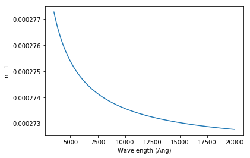

```python
nlam = 1000
lamstart = 3500.
lamend = 20000.
lam = lamstart + (lamend - lamstart) * np.arange(nlam) / np.float32(nlam - 1)
n = local_ref(lam=lam)
plt.plot(lam, n - 1.)
plt.xlabel('Wavelength (Ang)')
plt.ylabel('n - 1')
```

```
Text(0,0.5,'Spherical minus Plane-parallal (arcsec)')
```

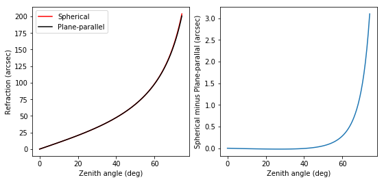

```python
nz = 100
z = 75. * np.arange(nz) / np.float32(nz)
Rpp = refraction_pp(z=z)
R = refraction(z=z)
fig, ax = plt.subplots(1, 2, figsize=(9, 4))
ax[0].plot(z, R, color='red', label='Spherical')
ax[0].plot(z, Rpp, color='black', label='Plane-parallel')
ax[0].set_xlabel("Zenith angle (deg)")
ax[0].set_ylabel("Refraction (arcsec)")
ax[0].legend()
ax[1].plot(z, R - Rpp)
ax[1].set_xlabel("Zenith angle (deg)")
ax[1].set_ylabel("Spherical minus Plane-parallal (arcsec)")
```

Now let us look at airmass 1.2, which is zenith angle of $z \approx 33$ deg, and consider the refraction as a function of wavelength.

The differential refraction across the optical and near-infrared bands is about 0.5 arcsec, not coincidentally about $10^{-2}$ of the total refraction effect (because this is the fractional variation of $n$ in that range). Between 4000 and 8000 Angstroms, the image shifts about 0.25 arcsec, in the sense that the bluer light is higher in the sky than the redder light.

Aside from a very slight overall difference of $\sim 0.02$ arcsec in the absolute refraction, the plane-parallel approximation captures the variation with wavelength very accurately.

```
Text(0,0.5,'Spherical minus Plane-parallal (arcsec)')
```

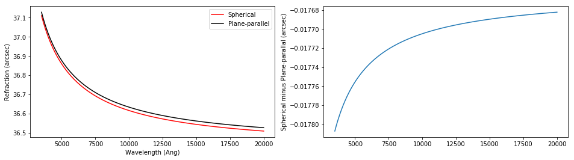

```python
z = 33.
Rpp = refraction_pp(z=z, lam=lam)
R = refraction(z=z, lam=lam)
fig, ax = plt.subplots(1, 2, figsize=(16, 4))
ax[0].plot(lam, R, color='red', label='Spherical')
ax[0].plot(lam, Rpp, color='black', label='Plane-parallel')
ax[0].set_xlabel("Wavelength (Ang)")
ax[0].set_ylabel("Refraction (arcsec)")
ax[0].legend()
ax[1].plot(lam, R - Rpp)
ax[0].set_xlabel("Wavelength (Ang)")
ax[1].set_ylabel("Spherical minus Plane-parallal (arcsec)")
```

## 2. Plot sky brightness vs airmass for SDSS imaging observations

*Based on answer by David Mykytyn*

We first define a function to retrieve the data we are interested in for a given run.

```python
def retrieve_camcol(run=756, camcol=3):
    # We define the columns we want and their
    columns = ('ra', 'dec', 'airmass_g', 'airmass_i', 'sky_g', 'sky_i', 'field')
    dtypes= ('f8', 'f8', 'f4', 'f4', 'f4', 'f4', 'i4')

    # Now define the query
    query = """
SELECT {columns}
FROM Field
WHERE run = {run} and camcol = {camcol}
"""
    query = query.format(columns=', '.join(list(columns)),
                         run=run, camcol=camcol)

    # Execute the query (requires internet access)
    responseStream = CasJobs.executeQuery(query, "DR12", format="dict")

    # convert result into astropy table
    result = responseStream['Result'][0]
    data = list(map(list, zip(*result['Data'])))
    fields = Table(data, names=columns, dtype=dtypes)
    isort = np.argsort(fields['field'])
    fields = fields[isort]
    return(fields)
```

Now we define a function to plot the asked-for results.

```python
def plot_sky(fields=None):
    field = fields['field']
    sky_g = 22.5 - 2.5 * np.log10(fields['sky_g'])
    sky_i = 22.5 - 2.5 * np.log10(fields['sky_i'])
    airmass_g = fields['airmass_g']
    airmass_i = fields['airmass_i']
    fig, axes = plt.subplots(2, 2, figsize=(10, 10))
    axes[0, 0].plot(field, sky_g)
    axes[0, 0].set_xlabel('Field Number')
    axes[0, 0].set_ylabel('g_band sky (mag/arcsec$^2$)')
    axes[0, 1].plot(airmass_g, sky_g, '.')
    axes[0, 1].set_xlabel('airmass g')
    axes[0, 1].set_ylabel('g_band sky (mag/arcsec$^2$)')
    axes[1, 0].plot(field, sky_i)
    axes[1, 0].set_xlabel('Field Number')
    axes[1, 0].set_ylabel('i_band sky (mag/arcsec$^2$)')
    axes[1, 1].plot(airmass_i, sky_i, '.')
    axes[1, 1].set_xlabel('airmass i')
    axes[1, 1].set_ylabel('i_band sky (mag/arcsec$^2$)')
```

First, let us consider a run that turns out to be taken at almost fixed airmass the entier time. We see substantial variation in sky brightness in both bands that correlates with field (time) in the same manner for both. This indicates sky that is coming from scattered light that is varying with time.

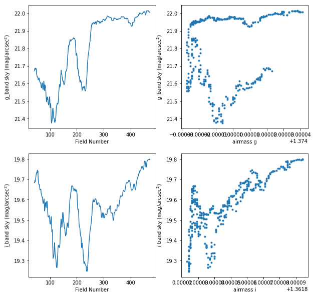

```python
fields = retrieve_camcol(run=4905)
plot_sky(fields)
```

But we can also consider a run where there is substantial variation of airmass. There is often a clear correlation of brightness with airmass. As you get further from zenith, you expect the brightness to increase. Note that this does not happen with the exact factor you expect (linear with airmass), because the sky is not uniform and it also varies, even for the $g$ band. For the $i$ band, the OH emission is even more variable in space and time, and so you see extra variation there.

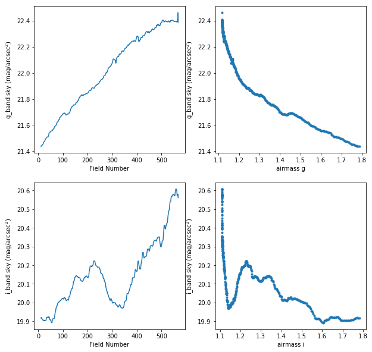

```python
fields = retrieve_camcol(run=4822)
plot_sky(fields)
```